# ICE Arrests: Illinois After January 20, 2025

Detention itineraries, transfer flows, and removal outcomes

Published

November 18, 2026

This report traces ICE arrests made in **Illinois** on or after **January 20, 2025** through the full detention and removal pipeline, using individual-level FOIA data from the [Deportation Data Project](https://deportationdata.org).

**7,758** arrests · **7,671** distinct individuals · **7,194** detention stays · **71.6%** ultimately removed

## Overview

### Monthly arrest volume

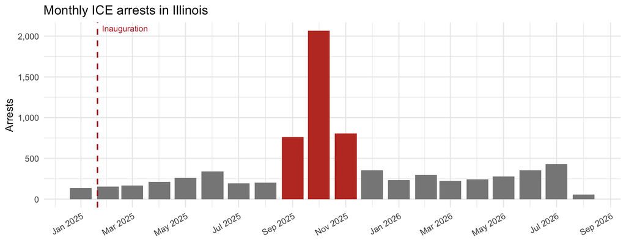

### Who was arrested

**Top nationalities**

| Country | N | % |
| --- | --- | --- |
| MEXICO | 3064 | 39.5 |
| VENEZUELA | 1276 | 16.4 |
| COLOMBIA | 607 | 7.8 |
| GUATEMALA | 530 | 6.8 |
| ECUADOR | 511 | 6.6 |
| HONDURAS | 285 | 3.7 |
| NICARAGUA | 268 | 3.5 |
| INDIA | 117 | 1.5 |
| EL SALVADOR | 95 | 1.2 |
| RUSSIA | 92 | 1.2 |
| POLAND | 75 | 1.0 |
| KYRGYZSTAN | 72 | 0.9 |
| CHINA, PEOPLES REPUBLIC OF | 70 | 0.9 |
| PERU | 62 | 0.8 |
| JORDAN | 44 | 0.6 |

**Arrest type**

| Arrest type | N | % |
| --- | --- | --- |
| At-Large Arrest | 6032 | 77.8 |
| Custodial Arrest | 1392 | 17.9 |
| Other | 316 | 4.1 |
| 287(g) Program | 18 | 0.2 |

**Criminality at arrest**

| Criminality | N | % |
| --- | --- | --- |
| 3 Other Immigration Violator | 4095 | 52.8 |
| 1 Convicted Criminal | 1861 | 24.0 |
| 2 Pending Criminal Charges | 1802 | 23.2 |

## Arrest Locations in Illinois

County-level map. When the release carries an apprehension city (Aug 2026 release) and a Census place-county crosswalk exists for the state, counties are attributed from the **arrest city** first and from `apprehension_site_landmark` second (validated against each state’s county list); records with non-specific landmarks (e.g. “SPM General Area”) use state-specific office rules where possible; others are excluded.

[interactive chart not shown]

> **Coverage:** 99% of arrests mapped to a county.

> **Caveat:** for at-large arrests the apprehension city can record the ICE processing point rather than the arrest location. Validation against the landmark field shows most city values are genuine arrest municipalities, but a few sites are dominated by processing locations — Broadview, IL (an ICE processing center; 63% of its rows are at-large) and Fort Snelling, MN (the MSP airport CDP, the top reported city for St. Paul general-area rows). Counties dominated by such sites should be read with that ambiguity in mind.

```
**County attribution:** City 98.6% · Unmapped 1.1% · Landmark 0.3%

**Unmapped arrests** ( 85  of  7758 ): City not found in state 56.5% · No city or landmark 20% · Field office area, non-specific 16.5% · Other / unresolved 7.1%



Table: Largest unmapped arrest locations

|Reason                          |Landmark                       |Type                            |  N|
|:-------------------------------|:------------------------------|:-------------------------------|--:|
|City not found in state         |CHI GENERAL AREA, NON-SPECIFIC |Field office area, non-specific | 34|
|Field office area, non-specific |CHI GENERAL AREA, NON-SPECIFIC |Field office area, non-specific | 14|
|Other / unresolved              |US Penitentiary Thomson        |Federal prison                  |  6|
|City not found in state         |INP GENERAL AREA, NON-SPECIFIC |Field office area, non-specific |  1|
|City not found in state         |STL GENERAL NON-SPECIFIC       |Field office area, non-specific |  1|
```

## Detention Facility Maps and Transfer Flows

**Blue dots** = first detention facility. **Orange dots** = last detention facility. **Grey lines** = transfer flows between facilities; line width is proportional to the log of the number of transfers on that route. Only flows with ≥ 7 transfers are shown.

[interactive chart not shown]

**First detention facility (top 8):**

| DETLOC | Facility | City | State | N | % |
| --- | --- | --- | --- | --- | --- |
| BSAHOLD | Broadview Service Staging | Broadview | IL | 5631 | 78.3 |
| CHIHOLD | Chicago Field Office | Chicago | IL | 553 | 7.7 |
| RIIHOLD | Rock Island Hold Room | Rock Island | IL | 393 | 5.5 |
| STLHOLD | St. Louis Holdroom | St. Louis | MO | 381 | 5.3 |
| FSF | Florence Staging Facility | Florence | AZ | 28 | 0.4 |
| EROFCB | Camp East Montana | El Paso | TX | 26 | 0.4 |
| INPHOLD | Indianapolis Hold Room | Indianapolis | IN | 18 | 0.3 |
| MILHOLD | Milwaukee Holdroom | Milwaukee | WI | 14 | 0.2 |

**Last detention facility (top 10):**

| DETLOC | Facility | City | State | N | % |
| --- | --- | --- | --- | --- | --- |
| JENATLA | Alexandria Staging Facility | Alexandria | LA | 938 | 13.0 |
| EROFCB | Camp East Montana | El Paso | TX | 911 | 12.7 |
| BSAHOLD | Broadview Service Staging | Broadview | IL | 535 | 7.4 |
| PIC | Port Isabel Detention Center | Los Fresnos | TX | 511 | 7.1 |
| NRLKCMI | North Lake Correctional Facility | Baldwin | MI | 433 | 6.0 |
| PINEPLA | Pine Prairie ICE Processing Center | Pine Prairie | LA | 307 | 4.3 |
| CLAYCIN | Clay County Justice Center | Brazil | IN | 279 | 3.9 |
| ADAMSMS | Adams County Detention Center (Mississippi) | Natchez | MS | 235 | 3.3 |
| LAWINCI | Winn Correctional Center | Winnfield | LA | 220 | 3.1 |
| JKPCCLA | Jackson Parish Correctional Center | Jonesboro | LA | 193 | 2.7 |

## Removal Pipeline Flow

Each band traces one group through the pipeline: **Illinois arrest → first facility → last facility → outcome.** Band width is proportional to number of stays.

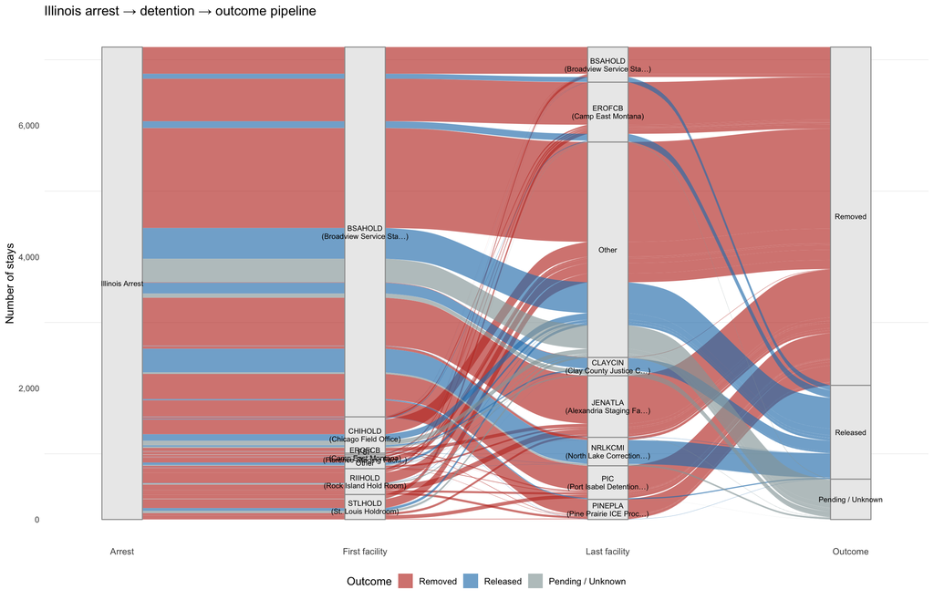

**Final outcomes:**

| Release reason | N | % |
| --- | --- | --- |
| Removed | 5151 | 71.6 |
| NA | 615 | 8.5 |
| Bonded Out - IJ | 600 | 8.3 |
| Court Ordered | 253 | 3.5 |
| Order of recognizance | 120 | 1.7 |
| Voluntary departure | 115 | 1.6 |
| U.S. Marshals or other agency (explain in Detention Comments) | 99 | 1.4 |
| Paroled | 92 | 1.3 |
| Order of supervision | 31 | 0.4 |
| Transferred | 31 | 0.4 |
| Relief Granted by IJ | 30 | 0.4 |
| Proceedings Terminated | 21 | 0.3 |
| Order of Recognizance - Humanitarian | 10 | 0.1 |
| Bonded Out - Field Office | 9 | 0.1 |
| ORR - Office of Refugee Resettlement | 4 | 0.1 |
| Order of Supervision - No SLRRFF | 3 | 0.0 |
| Paroled - Fear Found | 2 | 0.0 |
| Paroled - Humanitarian | 2 | 0.0 |
| Withdrawal | 2 | 0.0 |
| Died | 1 | 0.0 |
| Order of Supervision - Humanitarian | 1 | 0.0 |
| Order of Supervision - Re-Release | 1 | 0.0 |
| Voluntary Return | 1 | 0.0 |

**All facilities in itineraries (top 15):**

[output not shown]

## Removal Destinations

The heatmap below crosses **citizenship country** (columns) against **country deported to** (rows). Cell numbers are absolute counts; cell color shows what share of that row’s removals came from each citizenship group. Top 15 destinations × top 12 citizenships shown.

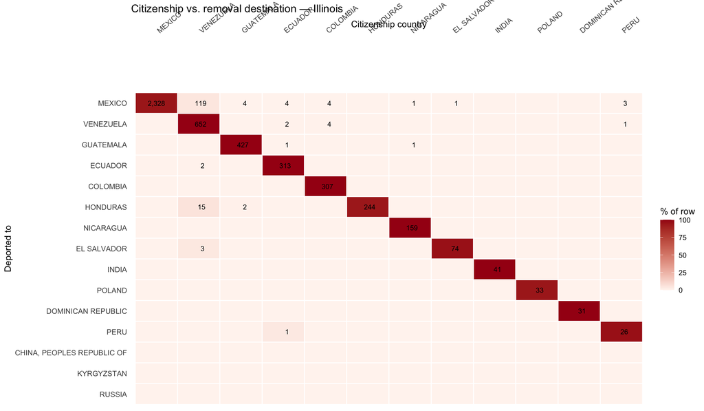

**Summary table:**

Removal destinations for Illinois arrests

| Country | N | % |
| --- | --- | --- |
| MEXICO | 2469 | 48.6 |
| VENEZUELA | 659 | 13.0 |
| GUATEMALA | 429 | 8.4 |
| ECUADOR | 315 | 6.2 |
| COLOMBIA | 307 | 6.0 |
| HONDURAS | 261 | 5.1 |
| NICARAGUA | 159 | 3.1 |
| EL SALVADOR | 77 | 1.5 |
| INDIA | 41 | 0.8 |
| POLAND | 35 | 0.7 |
| DOMINICAN REPUBLIC | 31 | 0.6 |
| PERU | 27 | 0.5 |
| CHINA, PEOPLES REPUBLIC OF | 26 | 0.5 |
| KYRGYZSTAN | 24 | 0.5 |
| RUSSIA | 14 | 0.3 |
| LITHUANIA | 12 | 0.2 |
| ROMANIA | 11 | 0.2 |
| JORDAN | 10 | 0.2 |
| NIGERIA | 10 | 0.2 |
| PHILIPPINES | 8 | 0.2 |

## Minor Detainees (Under 18)

**339 arrests** · **335 distinct individuals** · **122 detention stays.** Age is estimated as year(arrest) − birth year and may be off by up to one year.

| Metric | Value |
| --- | --- |
| Arrests of minors | 339 |
| Distinct minors | 335 |
| Detention stays | 122 |

**Age at arrest**

| Age | N |
| --- | --- |
| 2 | 1 |
| 3 | 8 |
| 4 | 16 |
| 5 | 23 |
| 6 | 31 |
| 7 | 19 |
| 8 | 28 |
| 9 | 21 |
| 10 | 19 |
| 11 | 20 |
| 12 | 38 |
| 13 | 27 |
| 14 | 17 |
| 15 | 19 |
| 16 | 25 |
| 17 | 27 |

**Nationality**

| Country | N | % |
| --- | --- | --- |
| COLOMBIA | 90 | 26.5 |
| VENEZUELA | 67 | 19.8 |
| ECUADOR | 58 | 17.1 |
| MEXICO | 30 | 8.8 |
| NICARAGUA | 19 | 5.6 |
| RUSSIA | 16 | 4.7 |
| GUATEMALA | 15 | 4.4 |
| HONDURAS | 10 | 2.9 |
| PERU | 9 | 2.7 |
| INDIA | 8 | 2.4 |
| EL SALVADOR | 4 | 1.2 |
| ROMANIA | 3 | 0.9 |
| JORDAN | 2 | 0.6 |
| KYRGYZSTAN | 2 | 0.6 |
| PAKISTAN | 2 | 0.6 |
| CHILE | 1 | 0.3 |
| DOMINICAN REPUBLIC | 1 | 0.3 |
| IRAN | 1 | 0.3 |
| NIGERIA | 1 | 0.3 |

**First detention facility**

| DETLOC | Facility | N | % |
| --- | --- | --- | --- |
| CHIHOLD | CHICAGO HOLD ROOM | 108 | 88.5 |
| BSAHOLD | BROADVIEW SERVICE STAGING | 9 | 7.4 |
| BLOJVTN | BLOUNT COUNTY JUVENILE DET CNTR | 1 | 0.8 |
| KRNRCTX | KARNES CO IMMIGRATION PROCESS CTR | 1 | 0.8 |
| SNDHOLD | SND DISTRICT STAGING | 1 | 0.8 |
| STFRCTX | SOUTH TEXAS FAM RESIDENTIAL CENTER | 1 | 0.8 |
| STLHOLD | ST. LOUIS HOLDROOM | 1 | 0.8 |

**Last detention facility**

| DETLOC | Facility | N | % |
| --- | --- | --- | --- |
| CHIHOLD | CHICAGO HOLD ROOM | 80 | 65.6 |
| STFRCTX | SOUTH TEXAS FAM RESIDENTIAL CENTER | 38 | 31.1 |
| BLOJVTN | BLOUNT COUNTY JUVENILE DET CNTR | 1 | 0.8 |
| BSAHOLD | BROADVIEW SERVICE STAGING | 1 | 0.8 |
| KRNRCTX | KARNES CO IMMIGRATION PROCESS CTR | 1 | 0.8 |
| STLHOLD | ST. LOUIS HOLDROOM | 1 | 0.8 |

**Outcomes**

| Release reason | N | % |
| --- | --- | --- |
| Removed | 72 | 59.0 |
| Voluntary departure | 25 | 20.5 |
| Order of recognizance | 10 | 8.2 |
| ORR - Office of Refugee Resettlement | 4 | 3.3 |
| NA | 4 | 3.3 |
| Paroled | 3 | 2.5 |
| Court Ordered | 1 | 0.8 |
| Order of Recognizance - Humanitarian | 1 | 0.8 |
| Order of supervision | 1 | 0.8 |
| U.S. Marshals or other agency (explain in Detention Comments) | 1 | 0.8 |